# Data Science Job salaries Breakdown

## Dataset Overview

This is a kaggle dataset downloaded via API and Extracted. The dataset has 607 rows and 11 columns. The columns range from year to salary to job loaction and other feature. The dataset has no nulls and it is tidy in terms of structure

## Average salary(in usd) in data science industry over the years

This graph shows the average for the data science jobs and it clearly shows that the average salary has been increasing each year and there was rather a drastic increase from 2021 to 2022 with an increase of 20K

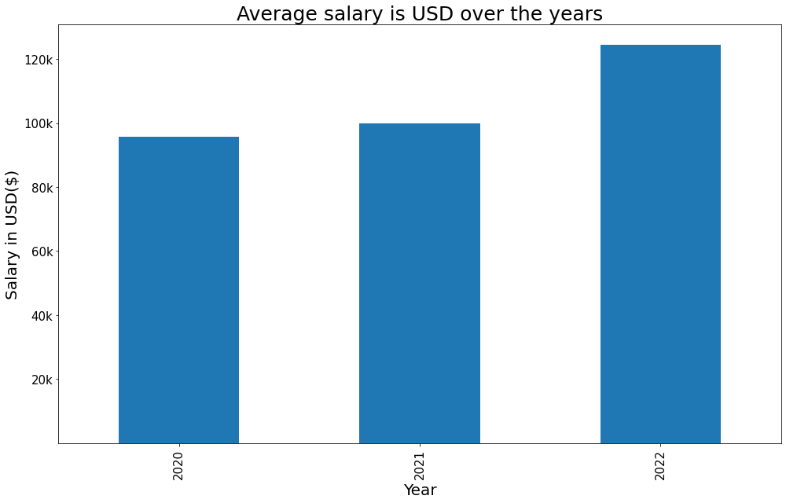

## Country with the most job entries

This graph clearly shows that USA has the most job entries with above 50% of the data coming from the US while a Great britain with second contributing about 8% of the data and the rest of the countries below 8%

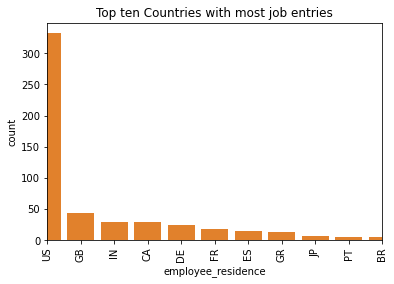

## The job which pays the most in the Data Science industry between 2020 and 2022 in usd

This graph depicts the highest or maximum salary for each job between the year 2020 to 2022. The top 3 highest earners are

1. Principal Data Engineer with over 600k per annum
2. Research Scientist and Financial Data Analyst above 400k per annum
3. Applied Machine Learning Scientist also above the 400k per annum

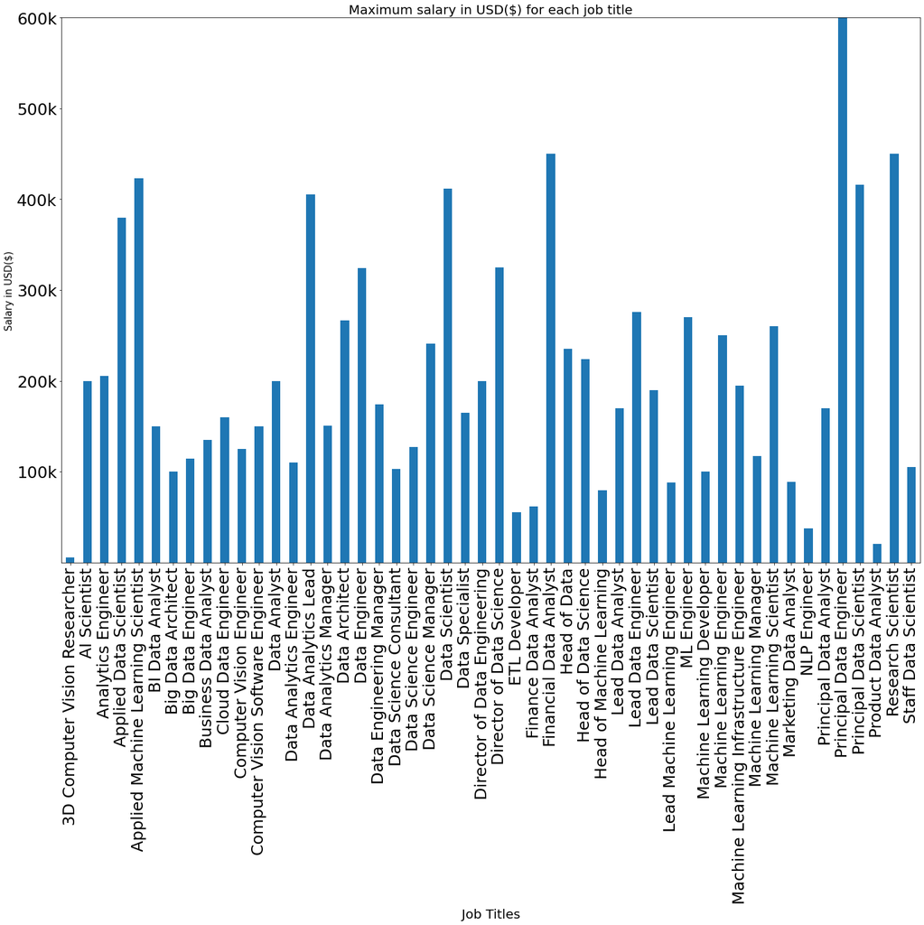

## The remote ratio each job

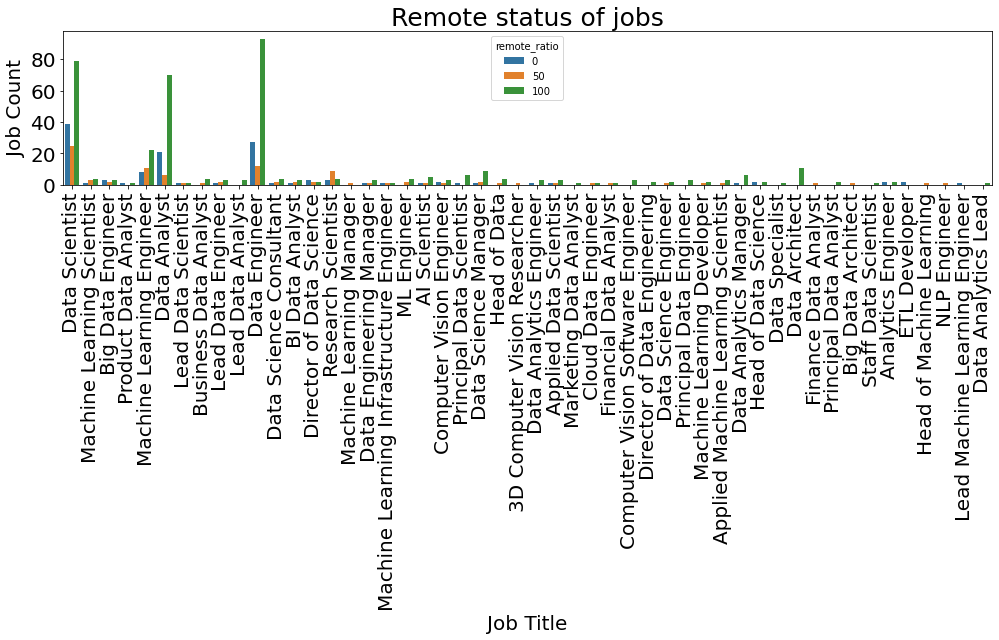

## The salaries based on remote ratio in different company sizes

This graphic shows the three company size and remote ratio for each company size as well as how much each remote ratio position earns in each company. In large sized companies , Remote data science Jobs get the highest pay and that is true as well for small and medium sized companies

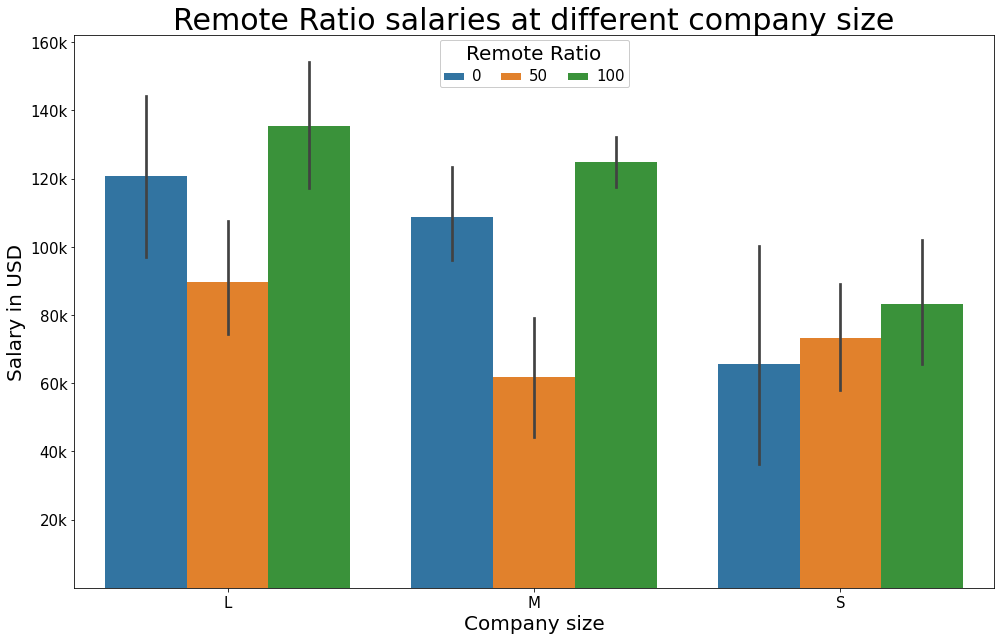

## Measuring salary by experience level over time

The experience level is key feature which determines how much you would earn. The highest earning experience level is Executive level followed by the senior level and then the middle (intermediate) and entry position. There is an decrease in 2021 for Senior ,middle and entry position while executive had its all time high in 2021. And whilst executive salaries decrease in 2022 , the other exprience levels have a slight increase going into 2022

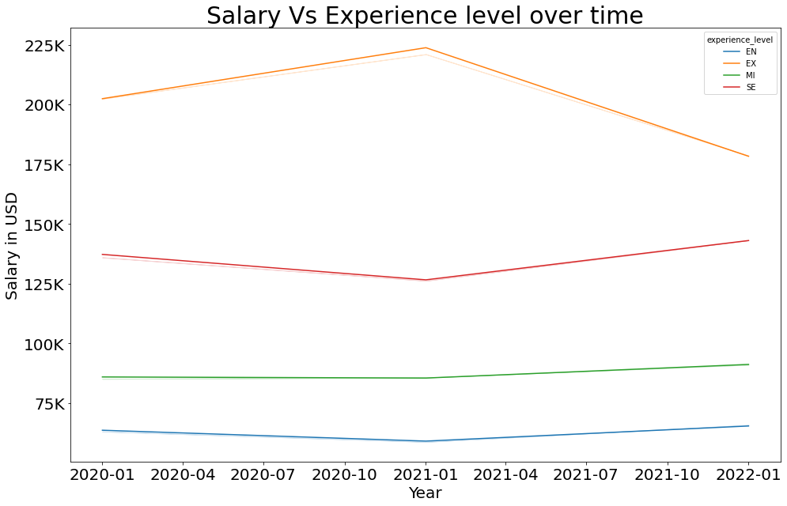